# 2-Beta Distribution

Andrew L

11/29/2021

# Notes

- probability distribution with parameters *$\alpha$* and $\beta%$
- domain of beta distribution is $(0,1)$
- represents a distribution of *probabilities*
  - all possible values of probabilities when we don’t know what that probability is
- Bayesian statistics is a way of modeling prior expectations explicitly

## Batting Average Example

### Updating

- number of hits player gets out of his at-bats is a **binomial distribution**
  - best way to represent the prior expectation with with beta distribution
  - a prior is representing, before the batter takes his first swing, what we roughly expect his batting average to be
- let’s say we expect a player’s season-long batting avg to be between .21 to .35
  - can be represented with beta dist. with parameters $\alpha = 81$ and $\beta = 219$

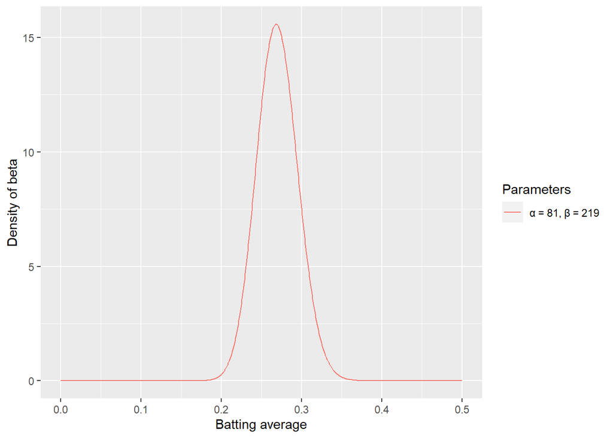

- x-axis represnts distribution of possible batting averages, and y-axis represents probaility density of the beta distribution
- every time we get new info (player gets a hit or miss), we *update* our probabilities (shift curve left or right)
  - this is the basic Bayesian philosophy: start with a prior dist., see some evidence, then update **posterior** dist.
- the new beta dist. will be updated as such:

$$Beta(\alpha_{0} + hits, \beta_{0} + misses)$$
where $\alpha_{0}$ and $\beta_{0}$ are parameters that we started with (81 and 219 respectively)

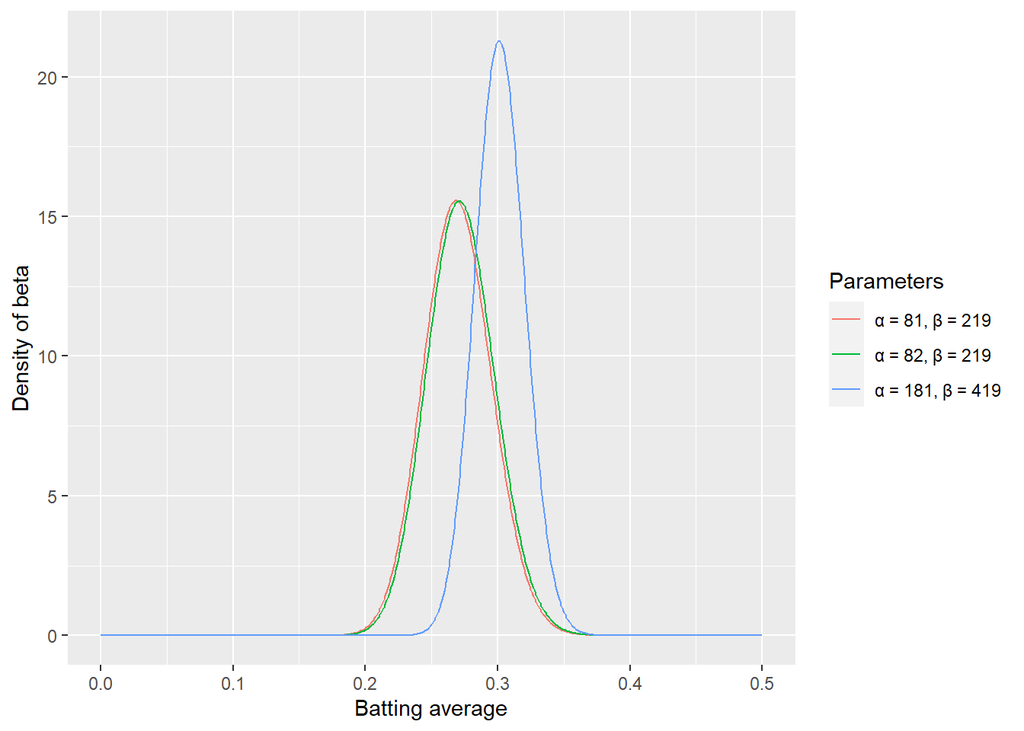

- we can see that a single hit ($\alpha_{0} + 1$) won’t shift the curve much at all
- a more drastic change would be Beta($\alpha_{0} + 100, \beta_{0} + 200$), indicated by the blue curve

### Posterior Mean

Expected value (mean) of beta distribution is:

$$\frac{\alpha}{\alpha + \beta}$$

So a player with 100 hits and 200 misses would have a expected value of the beta distribution:

$$\frac{82 + 100}{82 + 100 + 219 + 200} = .303$$

Note that it is lower than the raw estimate $\frac{100}{100+200} = .333$, but higher than the estimate we started with $\frac{81}{81+219} = .270$

- this means that the expected value is a combination of our prior expectations and our estimates
  - in other words, we’re saying that we start off each palyer in the season with 81 hits and 219 misses on his record

### Conjugate Prior

- Beta dist. is the **conjugate prior** of the binomial

Let’s simulate 10 million players with $\beta(81,219)$ distribution, and from each of them, we give them 300 chances at-bat, how many of these players will get exactly 100 hits?:

```r
library(dplyr)
num_trials <- 10e6
simulations <- data_frame(
true_average = rbeta(num_trials, 81, 219),
hits = rbinom(num_trials, 300, true_average)
)
simulations
```

```
## # A tibble: 10,000,000 x 2
##    true_average  hits
##           <dbl> <int>
##  1        0.265    73
##  2        0.233    76
##  3        0.238    76
##  4        0.259    85
##  5        0.302   102
##  6        0.279    81
##  7        0.242    72
##  8        0.241    55
##  9        0.262    91
## 10        0.266    70
## # ... with 9,999,990 more rows
```

```r
hit_100 <- simulations %>%
filter(hits == 100)

hit_100
```

```
## # A tibble: 79,484 x 2
##    true_average  hits
##           <dbl> <int>
##  1        0.305   100
##  2        0.299   100
##  3        0.332   100
##  4        0.290   100
##  5        0.310   100
##  6        0.323   100
##  7        0.291   100
##  8        0.276   100
##  9        0.316   100
## 10        0.302   100
## # ... with 79,474 more rows
```

What is the distribution of batting avgs among these selected 100/300 players?:

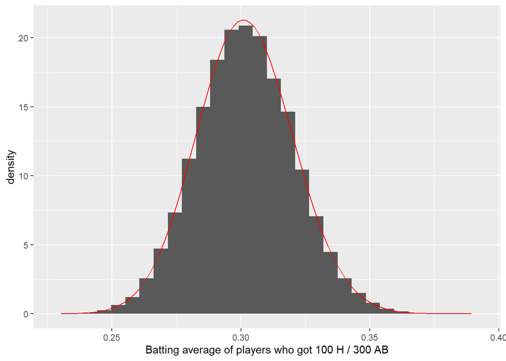

We can see that the distribution of players precisely matches our $\beta(81+100,219+200)$ posterior from the blue curve in the previous graph * Bayesian updating is essentially asking: “our of our prior, what kinds of players would end up with evidence like this?”

What if player had gotten 60 hits or 80 hits instead of 100? We can plot it:

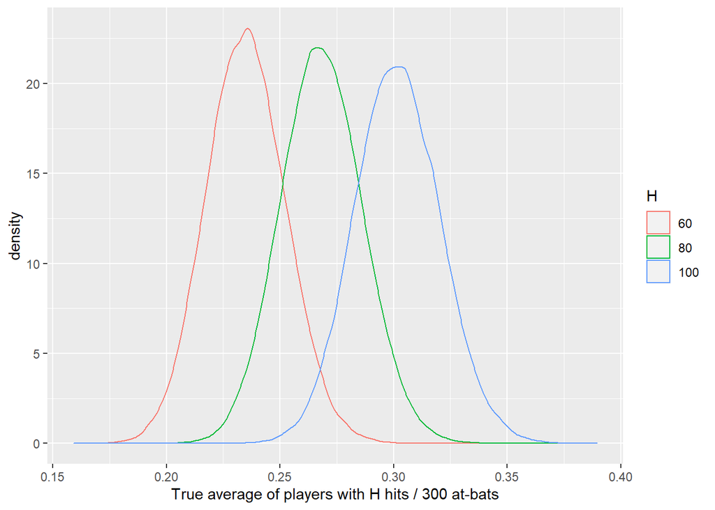

```r
simulations %>%
filter(hits %in% c(60, 80, 100)) %>%
ggplot(aes(true_average, color = factor(hits))) +
geom_density() +
labs(x = "True average of players with H hits / 300 at-bats",
color = "H")
```

We can see that the shape of posteriors are similar